```python
# Import libraries
import nltk
import pandas as pd
import numpy as np
import math
import sklearn
import matplotlib
import matplotlib.pyplot as plt
```

```python
# Setup matplotlib
%matplotlib inline
```

# 1. Datasets

**THE LIAR LIAR DATASET**

The LIAR dataset includes 12.8K human labeled short statements (average words per statemen 17) from POLITIFACT.COM’s API5, and each statement is evaluated by a POLITIFACT.COM editor for its truthfulness, structured in six fine-grained labels for the truthfulness ratings: pants-fire, false, barely-true, half-true, mostly-true, and true. These statements are sampled from various of contexts/venues, and the top categories include news releases, TV/radio interviews, campaign speeches, TV ads, tweets, debates, Facebook posts, etc. To ensure a broad coverage of the topics, there is also a diverse set of subjects discussed by the speakers. The top-10 most discussed subjects in the dataset are economy, healthcare, taxes, federal-budget, education, jobs, statebudget, candidates-biography, elections, and immigration. For the purpose of our work, which aims in developing a ML model to detect fake news based on linguistic and NLP related features of a text source, we will consider only 2 possible classifications of the dataset rows whose label is 'true' or 'false'. By selecting these classifications we obtain a balanced distributed database of 3 671 instances of opposed news, which are 'explicitly' labeled false for 1995 or true 1676 for instances.

Noting that fact-checking is not a classic labeling task in NLP, the challenge of developing a ML model of text classification to detect automaticly fake from real news based on linguistic features of the text corpus of the source news, with respect to the limitations of our dataset is:

*Can we develop a model for fake news detection from a real-world collection of short statements of eterogeneous subjects that can be consistent with larger datasets?*

To do so we extracted and analysed different NLP features and we tested and compared the performance of different classification models based on accuracy of prediction.

After having explored the best combination of features parameters and the best performance of the different classifiers we generalized our findings testing the model on a larger dataset: Fake or Real dataset.

**FAKE OR REAL DATASET**

## 1.1 'Liar Liar' dataset

```python
# Import 'Liar Liar' dataset
# Note: the dataset has already been splitted in train and test dataset
liar_ds_train = pd.read_csv('datasets/liar/train.tsv', delimiter='\t', header=None)
liar_ds_test = pd.read_csv('datasets/liar/test.tsv', delimiter='\t', header=None)
```

```python
# Retrieve text (X) and label (Y) columns
# Only 'true' and 'false' values
# Only text (index=1) and labels (index=2) are mantained

# Train dataset
liar_ds_train = liar_ds_train.loc[liar_ds_train[1].isin(['true', 'false']), 1:2]
# Test dataset
liar_ds_test = liar_ds_test.loc[liar_ds_test[1].isin(['true', 'false']), 1:2]
```

```python
# Check train dataset
liar_ds_train.head()
```

|  | 1 | 2 |
| --- | --- | --- |
| 0 | false | Says the Annies List political group supports ... |
| 3 | false | Health care reform legislation is likely to ma... |
| 5 | true | The Chicago Bears have had more starting quart... |
| 12 | false | When Mitt Romney was governor of Massachusetts... |
| 16 | true | McCain opposed a requirement that the governme... |

```python
# Check test dataset
liar_ds_test.head()
```

|  | 1 | 2 |
| --- | --- | --- |
| 0 | true | Building a wall on the U.S.-Mexico border will... |
| 1 | false | Wisconsin is on pace to double the number of l... |
| 2 | false | Says John McCain has done nothing to help the ... |
| 5 | true | Over the past five years the federal governmen... |
| 6 | true | Says that Tennessee law requires that schools ... |

```python
# Define X (inputctext ) and Y (label) variables for each dataset

# Train dataset
X_train_liar = liar_ds_train[2]
Y_train_liar = liar_ds_train[1]
# Test dataset
X_test_liar = liar_ds_test[2]
Y_test_liar = liar_ds_test[1]
```

```python
# Labels falues must be turned into 0|1 form 'false'|'true'
from sklearn.preprocessing import LabelEncoder

le = LabelEncoder().fit(['false', 'true'])
# Encode labels
Y_train_liar = le.transform(Y_train_liar)
Y_test_liar = le.transform(Y_test_liar)
```

```
<BarContainer object of 2 artists>
```

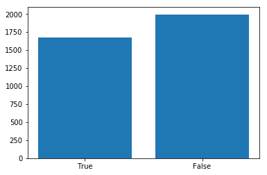

```python
# Show training dataset Y labels distribution
plt.bar(['True', 'False'], [len([y for y in Y_train_liar if y]), len([y for y in Y_train_liar if not y])])
```

```
<BarContainer object of 2 artists>
```

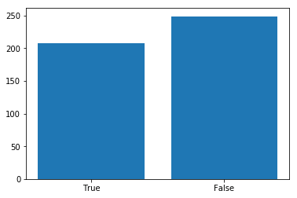

```python
# Show testing dataset Y labels distribution
plt.bar(['True', 'False'], [len([y for y in Y_test_liar if y]), len([y for y in Y_test_liar if not y])])
```

## 1.2 'Fake or Real' dataset

```python
# Import 'Fake or Real' dataset
fake_or_real_ds = pd.read_csv('datasets/fake_or_real_news/fake_or_real_news.csv', delimiter=',', header=0)
```

```python
# Show dataset
fake_or_real_ds.head()
fake_or_real_ds['text'].sum()
```

```python
# Define X (input text) and Y (label) variables

X_fake_or_real = fake_or_real_ds['text']
Y_fake_or_real = fake_or_real_ds['label']
```

```python
# Encode the label from 'FAKE'|'REAL' to 0|1
from sklearn.preprocessing import LabelEncoder

Y_fake_or_real = LabelEncoder().fit(['FAKE', 'REAL']).transform(Y_fake_or_real)
```

```
<BarContainer object of 2 artists>
```

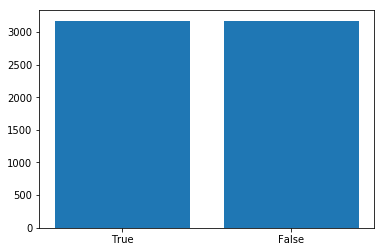

```python
# Show dataset Y labels distribution
plt.bar(['True', 'False'], [len([y for y in Y_fake_or_real if y]), len([y for y in Y_fake_or_real if not y])])
```

```python
# Split dataset into training and testing
from sklearn.model_selection import train_test_split

X_train_fake_or_real, X_test_fake_or_real, Y_train_fake_or_real, Y_test_fake_or_real = train_test_split(
    X_fake_or_real, Y_fake_or_real, test_size = 0.2, random_state = 0
)
```

```
<BarContainer object of 2 artists>
```

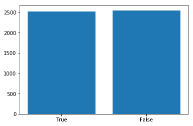

```python
# Show train dataset Y labels distribution
plt.bar(['True', 'False'], [len([y for y in Y_train_fake_or_real if y]), len([y for y in Y_train_fake_or_real if not y])])
```

```
<BarContainer object of 2 artists>
```

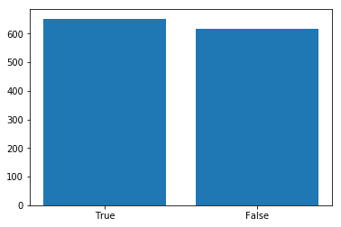

```python
# Show test dataset Y labels distribution
plt.bar(['True', 'False'], [len([y for y in Y_test_fake_or_real if y]), len([y for y in Y_test_fake_or_real if not y])])
```

# 2. Features

## 2.1 Feature extraction

### 2.1.1 Bag Of Words (BOW)

**LIAR LIAR DATASET**

```python
# Import CountVectorizer: an object which handles BOW automatically
from sklearn.feature_extraction.text import CountVectorizer
```

```python
# Get few rows of liar dataset (just to show bag of words)
X_train = X_train_liar[0:2]
Y_train = Y_train_liar[0:2]
```

```python
# Compute BOW for Liar Liar Dataset
cv = CountVectorizer().fit(X_train, Y_train)
# Show first row before transformation
print('Original string: "{}"'.format(X_train[0]))
# Vectorize rows
X_train = cv.transform(X_train)
# Show first row vectorized
X_train_array = X_train.toarray()
print('Becomes vector:\n{}'.format(X_train_array[0, :]))
print('of words:\n{}'.format(cv.get_feature_names()))
```

```
Original string: "Says the Annies List political group supports third-trimester abortions on demand."
Becomes vector:
[1 1 0 0 1 0 1 0 0 0 0 1 0 1 1 0 1 0 1 0 1 1 0 1]
of words:
['abortions', 'annies', 'care', 'change', 'demand', 'free', 'group', 'health', 'is', 'legislation', 'likely', 'list', 'mandate', 'on', 'political', 'reform', 'says', 'sex', 'supports', 'surgeries', 'the', 'third', 'to', 'trimester']
```

**FAKE OR REAL DATASET**

```python
#lets extract some basic BOW default features for both our datasets
from sklearn.feature_extraction.text import CountVectorizer
cv1=CountVectorizer()
#liar liar dataset
X_train_liar_c=cv1.fit_transform(X_train_liar)
X_test_liar_c=cv1.fit_transform(X_test_liar)
#fake or real dataset
X_train_fake_or_real_c=cv1.fit_transform(X_train_fake_or_real)
X_test_fake_or_real_c=cv1.fit_transform(X_test_fake_or_real)
```

### 2.1.2 TF-IDF

```python
# Using the example above, TF-IDF matrix is computed using TfidfVectorizer
# It is an object which computes automatically the weighting of a BOW matrix
from sklearn.feature_extraction.text import TfidfVectorizer
tf=TfidfVectorizer()
#liar liar dataset
X_train_liar_t=tf.fit_transform(X_train_liar)
X_test_liar_t=tf.fit_transform(X_test_liar)
#fake or real dataset
X_train_fake_or_real_t=tf.fit_transform(X_train_fake_or_real)
X_test_fake_or_real_t=tf.fit_transform(X_test_fake_or_real)
```

## 3. General Overview

In the following cells we give an overview of the general accuracy level of prediction of fake from real news taking in consideration two basic set of features extracted from the text corpus of our dataset (BOW and TF-IDF) and some basic classifiers(SVM - SVC, Linear SVC, MultinomialNB and Logistic Regression). As a general overview we can spot the challenge of our work, given the limitations of a short-statement dataset the classifications of which were developed mainly for fact checking based on real world sources rather than linguistic based automatic fake news detection.

The general accuracy of the model for BOW features attests just above the human paring level.

Better performing results attest for the TFIDF features, making them our candidate for more exploratory analysis for improvement of our models.

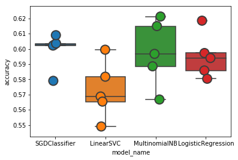

```
model_name
LinearSVC             0.572870
LogisticRegression    0.595205
MultinomialNB         0.597653
SGDClassifier         0.599291
Name: accuracy, dtype: float64
```

```python
#BOW models accuracy with default parameters and without feature selection for Liar Liar Dataset
from sklearn.linear_model import LogisticRegression
from sklearn.linear_model import SGDClassifier
from sklearn.svm import LinearSVC
from sklearn.naive_bayes import MultinomialNB
import matplotlib.pyplot as plt

from sklearn.model_selection import cross_val_score

models = [
    SGDClassifier(loss='hinge', penalty='l2',alpha=1e-3, random_state=42, max_iter=5, tol=None),
    LinearSVC(),
    MultinomialNB(),
    LogisticRegression(random_state=0),
]
CV = 5
cv_df = pd.DataFrame(index=range(CV * len(models)))
entries = []
for model in models:
  model_name = model.__class__.__name__
  accuracies = cross_val_score(model, X_train_liar_c, Y_train_liar, scoring='accuracy', cv=CV)
  for fold_idx, accuracy in enumerate(accuracies):
    entries.append((model_name, fold_idx, accuracy))
cv_df = pd.DataFrame(entries, columns=['model_name', 'fold_idx', 'accuracy'])

import seaborn as sns

sns.boxplot(x='model_name', y='accuracy', data=cv_df)
sns.stripplot(x='model_name', y='accuracy', data=cv_df,
              size=15, jitter=True, edgecolor="gray", linewidth=2)
plt.show()
cv_df.groupby('model_name').accuracy.mean()
```

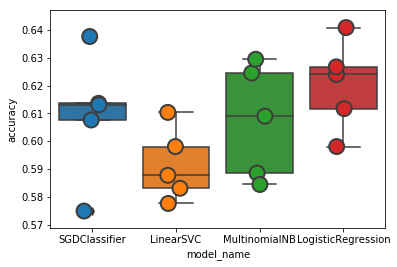

```
model_name
LinearSVC             0.591393
LogisticRegression    0.620261
MultinomialNB         0.607187
SGDClassifier         0.609370
Name: accuracy, dtype: float64
```

```python
#TF IDF models accuracy with default parameters and without feature selection for Liar Liar Dataset
from sklearn.linear_model import LogisticRegression
from sklearn.linear_model import SGDClassifier
from sklearn.svm import LinearSVC
from sklearn.naive_bayes import MultinomialNB
import matplotlib.pyplot as plt

from sklearn.model_selection import cross_val_score

models = [
    SGDClassifier(loss='hinge', penalty='l2',alpha=1e-3, random_state=42, max_iter=5, tol=None),
    LinearSVC(),
    MultinomialNB(),
    LogisticRegression(random_state=0),
]
CV = 5
cv_df = pd.DataFrame(index=range(CV * len(models)))
entries = []
for model in models:
  model_name = model.__class__.__name__
  accuracies = cross_val_score(model, X_train_liar_t, Y_train_liar, scoring='accuracy', cv=CV)
  for fold_idx, accuracy in enumerate(accuracies):
    entries.append((model_name, fold_idx, accuracy))
cv_df = pd.DataFrame(entries, columns=['model_name', 'fold_idx', 'accuracy'])

import seaborn as sns

sns.boxplot(x='model_name', y='accuracy', data=cv_df)
sns.stripplot(x='model_name', y='accuracy', data=cv_df,
              size=15, jitter=True, edgecolor="gray", linewidth=2)
plt.show()
cv_df.groupby('model_name').accuracy.mean()
```

## 2.2 Feature selection using TF-IDF and Chi2

With respect to the task of features extraction from a dataset a general observation about the correlation of the features with respect to the classification task has to be done. In fact features of a dataset can be:

1. Relevant features: shortly those that we need to perform well
2. Irrelevant features: those that are simply unnecessary
3. Redundant features: those that become irrelevant in the presence of others

To tackle this problem two approaches can be performed to improve the accuracy of the classification, one regarding feature engineering, that with respect to the scope of this development has been done by applying the tf-idf method to extract the features from the text corpus, and a feature selection approache based on statistical relevance of features.

The potential benefits of feature selection:

1. Improve Accuracy
2. Reduce Computation
3. Reduce Space
4. Reduce Cost of future measurements
5. Improved data/model understanding

In the following a method for feature selection is proposed with the application of chi-squared feature selection. The chi-square test is a statistical test of independence to determine the dependency of two variables.

From the definition, of chi-square we can easily deduce the application of chi-square technique in feature selection. Suppose you have a target variable (i.e., the class label) and some other features (feature variables) that describes each sample of the data. Now, we calculate chi-square statistics between every feature variable and the target variable and observe the existence of a relationship between the variables and the target. If the target variable is independent of the feature variable, we can discard that feature variable. If they are dependent, the feature variable is very important.

To check the correlation of our features we used the function of Scikit-learn SelectKBest, that selects the best features correlated with the accuracy of a Classifier.

```
Text(0.5,0,'$\\chi^2$')
```

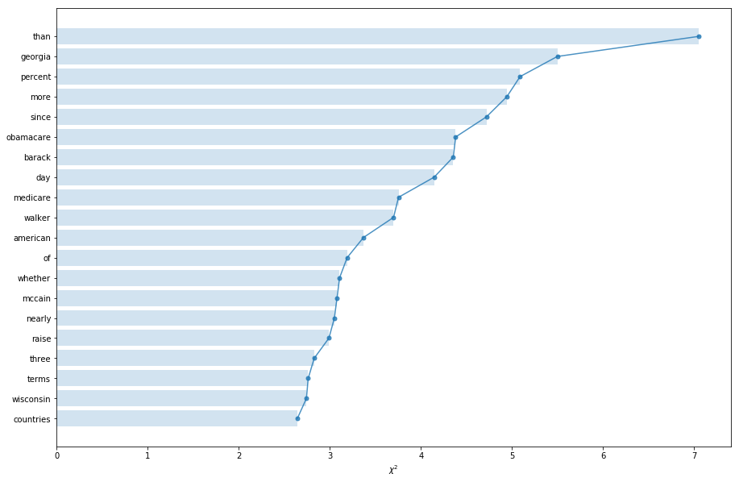

```python
#TF-IDF CHI2 FEATURE SELECTION VISUALIZATION for Liar liar dataset
from sklearn.feature_selection import chi2
from sklearn.feature_extraction.text import TfidfVectorizer

tvec = TfidfVectorizer()
x_train_tfidf = tvec.fit_transform(X_train_liar)
x_test_tfidf = tvec.transform(X_test_liar)
chi2score = chi2(x_train_tfidf, Y_train_liar)[0]

plt.figure(figsize=(15,10))
wscores = zip(tvec.get_feature_names(), chi2score)
wchi2 = sorted(wscores, key=lambda x:x[1])
topchi2 = list(zip(*wchi2[-20:]))
x = range(len(topchi2[1]))
labels = topchi2[0]
plt.barh(x,topchi2[1], align='center', alpha=0.2)
plt.plot(topchi2[1], x, '-o', markersize=5, alpha=0.8)
plt.yticks(x, labels)
plt.xlabel('$\chi^2$')
```

```
Text(0.5,0,'$\\chi^2$')
```

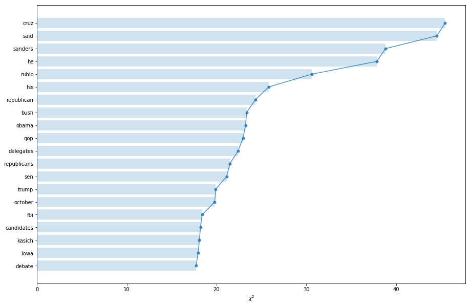

```python
#TF-IDF CHI2 FEATURE SELECTION VISUALIZATION for Fake or Real
from sklearn.feature_selection import chi2
from sklearn.feature_extraction.text import TfidfVectorizer

tvec = TfidfVectorizer()
x_train_tfidf = tvec.fit_transform(X_train_fake_or_real)
x_test_tfidf = tvec.transform(X_test_fake_or_real)
chi2score = chi2(x_train_tfidf, Y_train_fake_or_real)[0]

plt.figure(figsize=(15,10))
wscores = zip(tvec.get_feature_names(), chi2score)
wchi2 = sorted(wscores, key=lambda x:x[1])
topchi2 = list(zip(*wchi2[-20:]))
x = range(len(topchi2[1]))
labels = topchi2[0]
plt.barh(x,topchi2[1], align='center', alpha=0.2)
plt.plot(topchi2[1], x, '-o', markersize=5, alpha=0.8)
plt.yticks(x, labels)
plt.xlabel('$\chi^2$')
```

## MULTINOMIALNB with chi2 Feature Selection

## 1. Liar Liar Dataset

```python
from sklearn.feature_extraction.text import CountVectorizer
from sklearn.feature_extraction.text import TfidfTransformer
from sklearn.feature_selection import SelectKBest, chi2
from sklearn.metrics import accuracy_score,classification_report
from sklearn.naive_bayes import MultinomialNB
from sklearn.pipeline import Pipeline
from sklearn.feature_extraction.text import TfidfTransformer

nb = Pipeline([('vect', CountVectorizer()),
               ('chi2', SelectKBest(chi2, k=700)),
               ('tfidf', TfidfTransformer(use_idf=False)),
               ('clf', MultinomialNB()),
              ])
nb.fit(X_train_liar, Y_train_liar)


from sklearn.metrics import classification_report
y_pred = nb.predict(X_test_liar)

print('accuracy %s' % accuracy_score(y_pred, Y_test_liar))
print(classification_report(Y_test_liar, y_pred))
```

```
accuracy 0.6389496717724289
             precision    recall  f1-score   support

          0       0.65      0.74      0.69       249
          1       0.62      0.52      0.57       208

avg / total       0.64      0.64      0.63       457
```

## 2. Fake or Real Dataset

```python
from sklearn.feature_extraction.text import CountVectorizer
from sklearn.feature_extraction.text import TfidfTransformer
from sklearn.feature_selection import SelectKBest, chi2
from sklearn.metrics import accuracy_score,classification_report
from sklearn.naive_bayes import MultinomialNB
from sklearn.pipeline import Pipeline
from sklearn.feature_extraction.text import TfidfTransformer

nb = Pipeline([('vect', CountVectorizer()),
               ('tfidf', TfidfTransformer()),
               ('chi2', SelectKBest(chi2, k=200)),
               ('tfidf', TfidfTransformer()),
               ('clf', MultinomialNB()),
              ])
nb.fit(X_train_fake_or_real, Y_train_fake_or_real)


from sklearn.metrics import classification_report
y_pred = nb.predict(X_test_fake_or_real)

print('accuracy %s' % accuracy_score(y_pred, Y_test_fake_or_real))
print(classification_report(Y_test_fake_or_real, y_pred))
```

```
accuracy 0.824782951854775
             precision    recall  f1-score   support

          0       0.78      0.88      0.83       615
          1       0.88      0.77      0.82       652

avg / total       0.83      0.82      0.82      1267
```

## SVM - SVC with chi2 Feature Selection

## 1. Liar Liar Dataset

```python
from sklearn.feature_selection import SelectKBest, chi2
from sklearn.metrics import accuracy_score,classification_report
from sklearn.feature_extraction.text import CountVectorizer
from sklearn.feature_extraction.text import TfidfTransformer
from sklearn.pipeline import Pipeline
from sklearn.linear_model import SGDClassifier

sgd = Pipeline([('vect', CountVectorizer()),
                ('tfidf', TfidfTransformer()),
                ('chi2', SelectKBest(chi2, k='all')),
                ('clf', SGDClassifier(loss='hinge', penalty='l2',alpha=1e-3, random_state=42, max_iter=5, tol=None)),])

sgd.fit(X_train_liar, Y_train_liar)



y_pred = sgd.predict(X_test_liar)

print('accuracy %s' % accuracy_score(y_pred, Y_test_liar))
print(classification_report(Y_test_liar, y_pred,))
```

```
accuracy 0.6170678336980306
             precision    recall  f1-score   support

          0       0.61      0.84      0.70       249
          1       0.65      0.35      0.45       208

avg / total       0.63      0.62      0.59       457
```

## 2. Fake or Real Dataset

```python
from sklearn.feature_selection import SelectKBest, chi2
from sklearn.metrics import accuracy_score,classification_report
from sklearn.feature_extraction.text import CountVectorizer
from sklearn.feature_extraction.text import TfidfTransformer
from sklearn.pipeline import Pipeline
from sklearn.linear_model import SGDClassifier

sgd = Pipeline([('vect', CountVectorizer()),
                ('tfidf', TfidfTransformer()),
                ('chi2', SelectKBest(chi2, k='all')),
                ('clf', SGDClassifier(loss='hinge', penalty='l2',alpha=1e-3, random_state=42, max_iter=5, tol=None)),])

sgd.fit(X_train_fake_or_real, Y_train_fake_or_real)



y_pred = sgd.predict(X_test_fake_or_real)

print('accuracy %s' % accuracy_score(y_pred, Y_test_fake_or_real))
print(classification_report(Y_test_fake_or_real, y_pred,))
```

```
accuracy 0.898973954222573
             precision    recall  f1-score   support

          0       0.88      0.91      0.90       615
          1       0.92      0.88      0.90       652

avg / total       0.90      0.90      0.90      1267
```

## Logistic Regression with chi2 feature selection

## 1. Liar Liar Dataset

```python
from sklearn.linear_model import LogisticRegression


logreg = Pipeline([('vect', CountVectorizer()),
                ('tfidf', TfidfTransformer()),
                ('chi2', SelectKBest(chi2, k=200)),
                ('clf', LogisticRegression(n_jobs=1, C=1e5)),
               ])
logreg.fit(X_train_liar, Y_train_liar)



y_pred = logreg.predict(X_test_liar)

print('accuracy %s' % accuracy_score(y_pred, Y_test_liar))
print(classification_report(Y_test_liar, y_pred,))
```

```
accuracy 0.6345733041575492
             precision    recall  f1-score   support

          0       0.64      0.75      0.69       249
          1       0.62      0.50      0.55       208

avg / total       0.63      0.63      0.63       457
```

## 2. Fake or Real Dataset

```python
from sklearn.linear_model import LogisticRegression


logreg = Pipeline([('vect', CountVectorizer()),
                ('tfidf', TfidfTransformer()),
                ('chi2', SelectKBest(chi2, k=200)),
                ('clf', LogisticRegression(n_jobs=1, C=1e5)),
               ])
logreg.fit(X_train_fake_or_real, Y_train_fake_or_real)



y_pred = logreg.predict(X_test_fake_or_real)

print('accuracy %s' % accuracy_score(y_pred, Y_test_fake_or_real))
print(classification_report(Y_test_fake_or_real, y_pred,))
```

```
accuracy 0.9123914759273876
             precision    recall  f1-score   support

          0       0.90      0.92      0.91       615
          1       0.92      0.90      0.91       652

avg / total       0.91      0.91      0.91      1267
```

## 2.3 Conclusions

In the following the results of the application of the chi2 feature selection have been summarized with respect to the different classificators. Overally a general improvement of accuracy can be seen across the performance of all the classifers.

The application of such a method has both pros and cons with respect to the task of building a reliable automatic ML model for text classification.

1. Pros: the chi squared feature selection in flexible and less expensive with respect to other methods in terms of code complexity and running time
1. Cons: the same flexibility stated as a pro is also a short coming for this method since is not model oriented and its application requires a phase of trial and error that cannot be easily automized

**Dataset/Classifers Accuracy with chi2 feature selection**

Liar Liar:

SVM – SVC 61.7%

Fake or Real:

MultinomialNB 82.5%

SVM – SVC 89.8%

Logistic Regression **91.23%**

## 3. Finding the best outcome

Since each classificator (and even every vectorizer) has its own parameters, it would be hard for one to test manually every possible combination of those parameters. To solve this problem, sklearn library provides GridSearchCV.

GridSearchCV provides the same methods as a normal sklearn's Machine Learning algroithm and gets used in the same way, however it is not a proper ML algorithm. It Takes as input a ML algorithm (or a pipeline) and some parameters, and tests the former with every combination of the latter. Like any ML algorithm it returns a score: the better according to every parameter combination.

It uses cross-validation on a user-defined k-fold, 3-fold by default.

```python
# Import grid search library
from sklearn.model_selection import GridSearchCV

# Import some required sklearn resources
from sklearn import metrics
from sklearn.metrics import accuracy_score

# Defines a function which takes as input a Machine Learning algorithm, a training and a testing dataset
# Trains the ML algorithm on the given training set
# Tests the ML algorithm on the given testing set
# As result computes a Confusion Martix and relative scores
# Returns trained ML algorithm
def train_test(ml, Xtrain, Ytrain, Xtest, Ytest):
    # Fits ml algorithm on training set
    ml.fit(Xtrain, Ytrain)
    # Predicts Y on Xtest
    Ypredict = ml.predict(Xtest)
    # Prints confusion matrix
    print('Confusion Matrix:\n{}'.format(metrics.confusion_matrix(Ytest, Ypredict)))
    # Prints accuracy
    print('Accuracy: {}'.format(accuracy_score(Ytest, Ypredict)))
    # returns trained algorithm
    return ml

# Defines a train_test wrapper function for GridSearchCV
# Just adds some optput info
def train_test_gs(gs, Xtrain, Ytrain, Xtest, Ytest):
    gs = train_test(gs, Xtrain, Ytrain, Xtest, Ytest)
    # Prints other info (best parameters)
    print('Obtained by GridSearchCV with the following parameters:')
    for pname in gs.best_params_:
         print(" - %s: %r" % (pname, gs.best_params_[pname]))
    # Returns trained ML algorithm
    return gs
```

## An example: LOGISTIC REGRESSION

**LIAR LIAR DATASET**

```python
# Trying to use Logistic Regression model with TF-IDF indexes
# computed on standard BOW
pl = Pipeline([
    ('vect', CountVectorizer()),
    ('tfidf', TfidfTransformer()),
    ('clf', LogisticRegression(n_jobs=1, C=1e5))
])

# Adding tfidf paramterers to be tuned
params = {
    'vect__ngram_range': [(1,1), (1,2), (1,3)],
    'tfidf__use_idf': [True, False]
}

# Training and testing
gs = GridSearchCV(pl, params, scoring='accuracy', cv=5, iid=False, n_jobs=-1)
gs = train_test_gs(gs, X_train_liar, Y_train_liar, X_test_liar, Y_test_liar)
```

```
Confusion Matrix:
[[158  91]
 [ 85 123]]
Accuracy: 0.6148796498905909
Obtained by GridSearchCV with the following parameters:
 - tfidf__use_idf: True
 - vect__ngram_range: (1, 3)
```

```python
# Trying to use Logistic Regression model with TF-IDF indexes
# computed on standard BOW
pl = Pipeline([
    ('vect', CountVectorizer()),
    ('tfidf', TfidfTransformer()),
    ('clf', LogisticRegression(n_jobs=1, C=1e5))
])

# Adding tfidf paramterers to be tuned
params = {
    'vect__ngram_range': [(1,1), (1,2), (1,3)],
    'tfidf__use_idf': [True, False]
}

# Training and testing
gs = GridSearchCV(pl, params, scoring='accuracy', cv=5, iid=False, n_jobs=-1)
gs = train_test_gs(gs, X_train_fake_or_real, Y_train_fake_or_real, X_test_fake_or_real, Y_test_fake_or_real)
```

```
Confusion Matrix:
[[576  39]
 [ 42 610]]
Accuracy: 0.936069455406472
Obtained by GridSearchCV with the following parameters:
 - tfidf__use_idf: True
 - vect__ngram_range: (1, 2)
```

## 3.1 A General Approach: A proposal

In the next cells a pipeline for automatic training of our model is proposed. We use a double selection of both feature parameters and classifier models hyperparameters to find the best outcome for our prediction model.

With respect to the features we consider the following parameters:

1.ngram_range : tuple (min_n, max_n)

```
The lower and upper boundary of the range of n-values for different n-grams to be extracted.
```

2.max_df : float in range [0.0, 1.0] or int, default=1.0

```
When building the vocabulary ignore terms that have a document frequency strictly higher than the given threshold (corpus-specific stop words). If float, the parameter represents a proportion of documents, integer absolute counts. This parameter is ignored if vocabulary is not None.
```

3.max_features : int or None, default=None

```
If not None, build a vocabulary that only consider the top max_features ordered by term frequency across the corpus.

This parameter is ignored if vocabulary is not None.
```

4.norm : ‘l1’, ‘l2’ or None, optional

```
Norm used to normalize term vectors. None for no normalization.
```

5.use_idf : boolean, default=True

```
Enable inverse-document-frequency reweighting.
```

On the other side with respect to the hyperparameters of each classification model we selected by trial and error some of the most commonly used hyperparameters to improve accuracy.

The whole process is based on a 5 fold cross validation implemented with grid search. This approach gives a general good base to explore the characteristics of the data and the performances of the features specifically withrespect to the classifier model and can help find the best parameters for fitting a prediction model on the data.

The main shortcomings of this approach consist of long running time since the parameters selection ncrease computation time in a combinatorial manner.

## Multinomial NB

```python
from sklearn.naive_bayes import MultinomialNB
from __future__ import print_function
from pprint import pprint
from time import time
import logging
import numpy as np
from sklearn.feature_extraction.text import CountVectorizer
from sklearn.feature_extraction.text import TfidfTransformer
from sklearn.model_selection import GridSearchCV
from sklearn.pipeline import Pipeline

pl = Pipeline([
    ('vect', CountVectorizer()),
    ('tfidf', TfidfTransformer()),
    ('clf', MultinomialNB()),
])

# uncommenting more parameters will give better exploring power but will
# increase processing time in a combinatorial way
params = {
    'vect__max_df': (0.20,0.25,0.5, 0.75, 1.0),
    'vect__max_features': (None, 5000, 10000, 50000),
    'vect__ngram_range': ((1, 1), (1, 2),(1,3)),  # unigrams or bigrams or trigrams
    'tfidf__use_idf': (True, False),
    'tfidf__norm': ('l1', 'l2'),
    #'clf__max_iter': (5,),
    'clf__alpha': (0.00001, 0.000001),
    #'clf__penalty': ('l1', 'l2'),
    #'clf__max_iter': (5,10),
    #'clf__C': np.logspace(-3,3,7),
    #'clf__dual':(True,False)
}
if __name__ == "__main__":
    # multiprocessing requires the fork to happen in a __main__ protected
    # block

    # find the best parameters for both the feature extraction and the
    # classifier
    grid_search = GridSearchCV(pl, params, cv=5,
                               n_jobs=-1, verbose=1)

    print("Performing grid search...")
    print("pipeline:", [name for name, _ in pl.steps])
    print("parameters:")
    pprint(params)
    t0 = time()
    grid_search.fit(X_train_liar, Y_train_liar)
    print("done in %0.3fs" % (time() - t0))
    print()

    print("Best score: %0.3f" % grid_search.best_score_)
    print("Best parameters set:")
    best_parameters = grid_search.best_estimator_.get_params()
    for param_name in sorted(params.keys()):
        print("\t%s: %r" % (param_name, best_parameters[param_name]))
```

```
Performing grid search...
pipeline: ['vect', 'tfidf', 'clf']
parameters:
{'clf__alpha': (1e-05, 1e-06),
 'tfidf__norm': ('l1', 'l2'),
 'tfidf__use_idf': (True, False),
 'vect__max_df': (0.2, 0.25, 0.5, 0.75, 1.0),
 'vect__max_features': (None, 5000, 10000, 50000),
 'vect__ngram_range': ((1, 1), (1, 2), (1, 3))}
Fitting 5 folds for each of 480 candidates, totalling 2400 fits
```

```
[Parallel(n_jobs=-1)]: Done  34 tasks      | elapsed:   25.3s
[Parallel(n_jobs=-1)]: Done 184 tasks      | elapsed:   44.9s
[Parallel(n_jobs=-1)]: Done 434 tasks      | elapsed:  1.3min
[Parallel(n_jobs=-1)]: Done 784 tasks      | elapsed:  2.0min
[Parallel(n_jobs=-1)]: Done 1234 tasks      | elapsed:  3.0min
[Parallel(n_jobs=-1)]: Done 1784 tasks      | elapsed:  4.1min
[Parallel(n_jobs=-1)]: Done 2400 out of 2400 | elapsed:  5.5min finished
```

```
done in 328.612s

Best score: 0.606
Best parameters set:
	clf__alpha: 1e-05
	tfidf__norm: 'l2'
	tfidf__use_idf: False
	vect__max_df: 0.75
	vect__max_features: 5000
	vect__ngram_range: (1, 3)
```

## Logistic Regression

```python
from __future__ import print_function

from pprint import pprint
from time import time
import logging
import numpy as np
from sklearn.feature_extraction.text import CountVectorizer
from sklearn.feature_extraction.text import TfidfTransformer
from sklearn.linear_model import LogisticRegression
from sklearn.model_selection import GridSearchCV
from sklearn.pipeline import Pipeline


pl = Pipeline([
    ('vect', CountVectorizer()),
    ('tfidf', TfidfTransformer()),
    ('clf', LogisticRegression()),
])

# uncommenting more parameters will give better exploring power but will
# increase processing time in a combinatorial way
params = {
    'vect__max_df': (0.20,0.25,0.5, 0.75, 1.0),
    'vect__max_features': (None, 5000, 10000, 50000),
    'vect__ngram_range': ((1, 1), (1, 2),(1,3)),  # unigrams or bigrams or trigrams
    #'tfidf__use_idf': (True, False),
    # 'tfidf__norm': ('l1', 'l2'),
    'clf__max_iter': (5,),
    #'clf__alpha': (0.00001, 0.000001),
    'clf__penalty': ('l1', 'l2'),
    #'clf__max_iter': (5,10),
    'clf__C': np.logspace(-3,3,7)
}
if __name__ == "__main__":
    # multiprocessing requires the fork to happen in a __main__ protected
    # block

    # find the best parameters for both the feature extraction and the
    # classifier
    grid_search = GridSearchCV(pl, params, cv=5,
                               n_jobs=-1, verbose=1)

    print("Performing grid search...")
    print("pipeline:", [name for name, _ in pl.steps])
    print("parameters:")
    pprint(params)
    t0 = time()
    grid_search.fit(X_train_liar, Y_train_liar)
    print("done in %0.3fs" % (time() - t0))
    print()

    print("Best score: %0.3f" % grid_search.best_score_)
    print("Best parameters set:")
    best_parameters = grid_search.best_estimator_.get_params()
    for param_name in sorted(params.keys()):
        print("\t%s: %r" % (param_name, best_parameters[param_name]))
```

```
Performing grid search...
pipeline: ['vect', 'tfidf', 'clf']
parameters:
{'clf__C': array([1.e-03, 1.e-02, 1.e-01, 1.e+00, 1.e+01, 1.e+02, 1.e+03]),
 'clf__max_iter': (5,),
 'clf__penalty': ('l1', 'l2'),
 'vect__max_df': (0.2, 0.25, 0.5, 0.75, 1.0),
 'vect__max_features': (None, 5000, 10000, 50000),
 'vect__ngram_range': ((1, 1), (1, 2), (1, 3))}
Fitting 5 folds for each of 840 candidates, totalling 4200 fits
```

```
[Parallel(n_jobs=-1)]: Done  34 tasks      | elapsed:   16.0s
[Parallel(n_jobs=-1)]: Done 184 tasks      | elapsed:   35.3s
[Parallel(n_jobs=-1)]: Done 434 tasks      | elapsed:  1.2min
[Parallel(n_jobs=-1)]: Done 784 tasks      | elapsed:  2.0min
[Parallel(n_jobs=-1)]: Done 1234 tasks      | elapsed:  3.1min
[Parallel(n_jobs=-1)]: Done 1784 tasks      | elapsed:  4.5min
[Parallel(n_jobs=-1)]: Done 2434 tasks      | elapsed:  6.1min
[Parallel(n_jobs=-1)]: Done 3184 tasks      | elapsed:  8.0min
[Parallel(n_jobs=-1)]: Done 4034 tasks      | elapsed: 10.4min
[Parallel(n_jobs=-1)]: Done 4200 out of 4200 | elapsed: 10.9min finished
```

```
done in 657.836s

Best score: 0.631
Best parameters set:
	clf__C: 1.0
	clf__max_iter: 5
	clf__penalty: 'l2'
	vect__max_df: 0.2
	vect__max_features: None
	vect__ngram_range: (1, 2)
```

## SVM SVC

```python
from __future__ import print_function

from pprint import pprint
from time import time
import logging
import numpy as np
from sklearn.feature_extraction.text import CountVectorizer
from sklearn.feature_extraction.text import TfidfTransformer
from sklearn.model_selection import GridSearchCV
from sklearn.pipeline import Pipeline

from sklearn.linear_model import SGDClassifier

pl = Pipeline([
    ('vect', CountVectorizer()),
    ('tfidf', TfidfTransformer()),
    ('clf', SGDClassifier(loss='hinge')),
])

# uncommenting more parameters will give better exploring power but will
# increase processing time in a combinatorial way
params = {
    'vect__max_df': (0.20,0.25,0.5, 0.75, 1.0),
    'vect__max_features': (None, 5000, 10000, 50000),
    'vect__ngram_range': ((1, 1), (1, 2),(1,3)),  # unigrams or bigrams or trigrams
    'tfidf__use_idf': (True, False),
    'tfidf__norm': ('l1', 'l2'),
    'clf__max_iter': (5,),
    'clf__alpha': (0.00001, 0.000001),
    'clf__penalty': ('l1', 'l2'),
    #'clf__max_iter': (5,10),

}
if __name__ == "__main__":
    # multiprocessing requires the fork to happen in a __main__ protected
    # block

    # find the best parameters for both the feature extraction and the
    # classifier
    grid_search = GridSearchCV(pl, params, cv=5,
                               n_jobs=-1, verbose=1)

    print("Performing grid search...")
    print("pipeline:", [name for name, _ in pl.steps])
    print("parameters:")
    pprint(params)
    t0 = time()
    grid_search.fit(X_train_liar, Y_train_liar)
    print("done in %0.3fs" % (time() - t0))
    print()

    print("Best score: %0.3f" % grid_search.best_score_)
    print("Best parameters set:")
    best_parameters = grid_search.best_estimator_.get_params()
    for param_name in sorted(params.keys()):
        print("\t%s: %r" % (param_name, best_parameters[param_name]))
```

```
Performing grid search...
pipeline: ['vect', 'tfidf', 'clf']
parameters:
{'clf__alpha': (1e-05, 1e-06),
 'clf__max_iter': (5,),
 'clf__penalty': ('l1', 'l2'),
 'tfidf__norm': ('l1', 'l2'),
 'tfidf__use_idf': (True, False),
 'vect__max_df': (0.2, 0.25, 0.5, 0.75, 1.0),
 'vect__max_features': (None, 5000, 10000, 50000),
 'vect__ngram_range': ((1, 1), (1, 2), (1, 3))}
Fitting 5 folds for each of 960 candidates, totalling 4800 fits
```

```
[Parallel(n_jobs=-1)]: Done  34 tasks      | elapsed:   15.6s
[Parallel(n_jobs=-1)]: Done 184 tasks      | elapsed:   36.2s
[Parallel(n_jobs=-1)]: Done 434 tasks      | elapsed:  1.1min
[Parallel(n_jobs=-1)]: Done 784 tasks      | elapsed:  1.9min
[Parallel(n_jobs=-1)]: Done 1234 tasks      | elapsed:  2.8min
[Parallel(n_jobs=-1)]: Done 1784 tasks      | elapsed:  4.0min
[Parallel(n_jobs=-1)]: Done 2434 tasks      | elapsed:  5.4min
[Parallel(n_jobs=-1)]: Done 3184 tasks      | elapsed:  7.0min
[Parallel(n_jobs=-1)]: Done 4034 tasks      | elapsed:  8.8min
[Parallel(n_jobs=-1)]: Done 4800 out of 4800 | elapsed: 10.4min finished
```

```
done in 624.642s

Best score: 0.632
Best parameters set:
	clf__alpha: 1e-05
	clf__max_iter: 5
	clf__penalty: 'l2'
	tfidf__norm: 'l1'
	tfidf__use_idf: True
	vect__max_df: 0.25
	vect__max_features: None
	vect__ngram_range: (1, 3)
```

## 3.2 Visulizing the results: Roc Auc Curves

After selecting the best combination of parameters for the features and hypermìparameters for the classifier we visualize the outcome with a graph considering Receiver Operating Characteristic (ROC) metric to evaluate classifier output quality. ROC curves typically feature true positive rate on the Y axis, and false positive rate on the X axis. This means that the top left corner of the plot is the “ideal” point - a false positive rate of zero, and a true positive rate of one. This is not very realistic, but it does mean that a larger area under the curve (AUC) is usually better.

The “steepness” of ROC curves is also important, since it is ideal to maximize the true positive rate while minimizing the false positive rate.

## Logistic Regression

```
Confusion Matrix:
[[190  59]
 [110  98]]
Accuracy: 0.6301969365426696
```

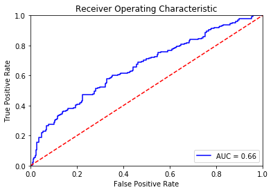

```python
from __future__ import print_function
from sklearn.metrics import roc_curve, auc
from sklearn.preprocessing import label_binarize
from pprint import pprint
from time import time
import logging
import numpy as np
from sklearn.datasets import fetch_20newsgroups
from sklearn.feature_extraction.text import CountVectorizer
from sklearn.feature_extraction.text import TfidfTransformer
from sklearn.linear_model import LogisticRegression
from sklearn.model_selection import GridSearchCV
from sklearn.pipeline import Pipeline

from sklearn.linear_model import SGDClassifier

pl = Pipeline([
    ('vect', CountVectorizer(max_df=(0.2),ngram_range=(1,2))),
    ('tfidf', TfidfTransformer(use_idf=True)),
    ('clf', LogisticRegression(C=1,max_iter=5,penalty='l2')),
])
train_test(pl,X_train_liar,Y_train_liar,X_test_liar,Y_test_liar)
# Compute ROC curve and ROC area for each class

probs = pl.predict_proba(X_test_liar)
preds = probs[:,1]
fpr, tpr, threshold = metrics.roc_curve(Y_test_liar, preds)#pos_label='true')
roc_auc = metrics.auc(fpr, tpr)

# method I: plt
import matplotlib.pyplot as plt
plt.title('Receiver Operating Characteristic')
plt.plot(fpr, tpr, 'b', label = 'AUC = %0.2f' % roc_auc)
plt.legend(loc = 'lower right')
plt.plot([0, 1], [0, 1],'r--')
plt.xlim([0, 1])
plt.ylim([0, 1])
plt.ylabel('True Positive Rate')
plt.xlabel('False Positive Rate')
plt.show()
```

## Multinomial NB

```
Confusion Matrix:
[[164  85]
 [ 97 111]]
Accuracy: 0.6017505470459519
```

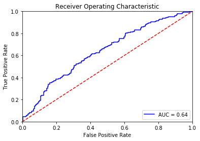

```python
from __future__ import print_function
from sklearn.metrics import roc_curve, auc
from sklearn.preprocessing import label_binarize
from pprint import pprint
from time import time
import logging
import numpy as np
from sklearn.feature_extraction.text import CountVectorizer
from sklearn.feature_extraction.text import TfidfTransformer
from sklearn.model_selection import GridSearchCV
from sklearn.pipeline import Pipeline


pl = Pipeline([
    ('vect', CountVectorizer(max_df=0.75,max_features=5000,ngram_range=(1,3))),
    ('tfidf', TfidfTransformer(norm= 'l2',use_idf=False)),
    ('clf', MultinomialNB(alpha= 1e-05)),
])

train_test(pl,X_train_liar,Y_train_liar,X_test_liar,Y_test_liar)
# Compute ROC curve and ROC area for each class

probs = pl.predict_proba(X_test_liar)
preds = probs[:,1]
fpr, tpr, threshold = metrics.roc_curve(Y_test_liar, preds)#pos_label='true')
roc_auc = metrics.auc(fpr, tpr)

# method I: plt
import matplotlib.pyplot as plt
plt.title('Receiver Operating Characteristic')
plt.plot(fpr, tpr, 'b', label = 'AUC = %0.2f' % roc_auc)
plt.legend(loc = 'lower right')
plt.plot([0, 1], [0, 1],'r--')
plt.xlim([0, 1])
plt.ylim([0, 1])
plt.ylabel('True Positive Rate')
plt.xlabel('False Positive Rate')
plt.show()
```